# Prediction-Assignment

Deborah Passey

7/28/2019

INTRODUCTION

Using devices such as Jawbone Up, Nike FuelBand, and Fitbit it is now possible to collect a large amount of data about personal activity relatively inexpensively. These type of devices are part of the quantified self movement – a group of enthusiasts who take measurements about themselves regularly to improve their health, to find patterns in their behavior, or because they are tech geeks. One thing that people regularly do is quantify how much of a particular activity they do, but they rarely quantify how well they do it.

The data set for this analysis is from:  
Ugulino, W.; Cardador, D.; Vega, K.; Velloso, E.; Milidiu, R.; Fuks, H. Wearable Computing: Accelerometers’ Data Classification of Body Postures and Movements. Proceedings of 21st Brazilian Symposium on Artificial Intelligence. Advances in Artificial Intelligence - SBIA 2012. In: Lecture Notes in Computer Science. , pp. 52-61. Curitiba, PR: Springer Berlin / Heidelberg, 2012. ISBN 978-3-642-34458-9. DOI: 10.1007/978-3-642-34459-6_6.

METHODS

This project uses data from accelerometers on the belt, forearm, arm, and dumbell of 6 participants. They were asked to perform barbell lifts correctly and incorrectly in 5 different ways. This data is used to predict whether participants did the exercise correctly or incorrectly.

This project uses two datsets: a training dataset with 19,622 observations of 53 variables, and a testing dataset of 20 observations of 53 variables. The data sets were cleaned up to removed variables that most of the observations missing.

```r
    setwd("C:/Users/Deborah Passey/Desktop")

    pml_training <- read.csv("pml-training.csv", na.strings = c("","NA","#DIV/0!"))
    pml_testing <- read.csv("pml-testing.csv", na.strings = c("","NA","#DIV/0!"))

    training <- pml_training[lapply(pml_training, function(x) sum(is.na(x)) / length(x) ) < 0.05]
    testing <- pml_testing[lapply(pml_testing, function(x) sum(is.na(x)) / length(x)) < 0.05]

    training_data <- training[,-c(1:7)]
    testing_data <- testing[,-c(1:7)]

    training_data$classe <- unclass(training_data$classe)
    testing_data$classe <- unclass(testing_data$classe)

    inTrain <- createDataPartition(y=training_data$classe, p=0.7,list = FALSE)
    train <- training_data[inTrain,]
    test <- training_data[-inTrain,]
```

Data Summary for Participants

In order to cut down on processing time and predictors, the dataset was trimmed down to a select number of variables. The research from Ugulino et al (2012) was used a selection algorithm to identify 16 variables that are potentially the best at predicting whether participants did the exercise correctly: (1) Sensor on the belt - acceleration, pitch, yaw, and roll, (2) Sensor on the arm - acceleration, pitch, yaw, and roll, (3) Sensor on the forearm - acceleration, pitch, yaw, and roll, and (4) Sensor on the dumbbell - accleraton, pitch, yaw, and roll.  
The data table below shows the average for each of the six participants. The table reports the average of the Euler angles: roll, pitch and yaw, and accelerometer (accel) data for the arm, dumbbell, forearm, and belt.

```r
    means <- training[,c("user_name", "roll_belt","roll_arm", "roll_dumbbell", "roll_forearm", "pitch_belt", "pitch_arm", "pitch_dumbbell", "pitch_forearm", "yaw_belt", "yaw_arm", "yaw_dumbbell", "yaw_forearm","total_accel_arm", "total_accel_belt", "total_accel_dumbbell","total_accel_forearm")]
    dataset <- means %>% group_by(user_name) %>% summarise_each(funs(mean))
    summ <- kable(dataset) %>%
    kable_styling(bootstrap_options = c("striped", "hover", "condensed", "responsive")) %>% scroll_box(width = "100%", height = "200px")
    summ
```

| user_name | roll_belt | roll_arm | roll_dumbbell | roll_forearm | pitch_belt | pitch_arm | pitch_dumbbell | pitch_forearm | yaw_belt | yaw_arm | yaw_dumbbell | yaw_forearm | total_accel_arm | total_accel_belt | total_accel_dumbbell | total_accel_forearm |
| --- | --- | --- | --- | --- | --- | --- | --- | --- | --- | --- | --- | --- | --- | --- | --- | --- |
| adelmo | 128.2869990 | -15.70269 | 61.688812 | 0.000000 | -41.396737 | 5.204404 | -22.903124 | 0.000000 | 156.7731244 | -26.316871 | -87.25352 | 0.00000 | 22.23124 | 18.129240 | 18.411870 | 40.83505 |
| carlitos | 1.1677410 | 50.81837 | 28.207232 | 39.716886 | 6.582005 | -13.245909 | 3.884116 | 12.446048 | -93.0259961 | 4.276141 | 38.95589 | 15.42912 | 26.66388 | 2.997108 | 7.054627 | 35.08580 |
| charles | 122.0277149 | -45.72347 | -3.803530 | -11.705710 | 15.762226 | -12.492098 | -7.397196 | 24.483634 | 7.3655062 | -31.928391 | 31.64890 | -64.17740 | 22.21352 | 18.391120 | 5.337104 | 30.01103 |
| eurico | -0.0102345 | 90.25534 | 6.832875 | -1.639225 | 3.358449 | -6.694892 | 6.481118 | 4.401209 | -87.2585668 | 46.479805 | 33.62308 | 38.14837 | 28.44072 | 3.242020 | 9.288925 | 34.25896 |
| jeremy | 0.7217578 | 0.00000 | 61.315148 | 108.166149 | 4.103906 | 0.000000 | -47.904785 | 0.125050 | -87.5118460 | 0.000000 | -73.20845 | 87.32715 | 30.23633 | 4.422693 | 29.922399 | 33.36655 |
| pedro | 125.2708812 | 52.65374 | -29.186737 | 83.750153 | 25.523372 | -1.840647 | 13.321590 | 27.137759 | -0.3736169 | 18.077609 | 109.24753 | 54.25502 | 23.87088 | 19.946360 | 10.108812 | 33.81609 |

RESULTS

```r
## GBM Model
  set.seed(200)
  control <- trainControl(method = "cv", number = 5)
  gbm_model <- train(classe ~ ., method = "gbm", data = train[,c("classe", "roll_belt","roll_arm", "roll_dumbbell", "roll_forearm", "pitch_belt", "pitch_arm", "pitch_dumbbell", "pitch_forearm", "yaw_belt", "yaw_arm", "yaw_dumbbell", "yaw_forearm","total_accel_arm", "total_accel_belt", "total_accel_dumbbell","total_accel_forearm")], trControl= control, verbose=FALSE)

## Linear Model
  set.seed(200)
  lm_model <‐ train(classe ~.,data = train[,c("classe", "roll_belt","roll_arm", "roll_dumbbell", "roll_forearm", "pitch_belt", "pitch_arm", "pitch_dumbbell", "pitch_forearm", "yaw_belt", "yaw_arm", "yaw_dumbbell", "yaw_forearm","total_accel_arm", "total_accel_belt", "total_accel_dumbbell","total_accel_forearm")],method="lm")

## Random Forest
  set.seed(200)
  control <- trainControl(method = "repeatedcv", number = 5, repeats = 3)
  rf_model <- train(classe ~ ., data = train[,c("classe", "roll_belt","roll_arm", "roll_dumbbell", "roll_forearm", "pitch_belt", "pitch_arm", "pitch_dumbbell", "pitch_forearm", "yaw_belt", "yaw_arm", "yaw_dumbbell", "yaw_forearm","total_accel_arm", "total_accel_belt", "total_accel_dumbbell","total_accel_forearm")], method = "rf", ntree = 10, trControl = control, verbose=FALSE)
```

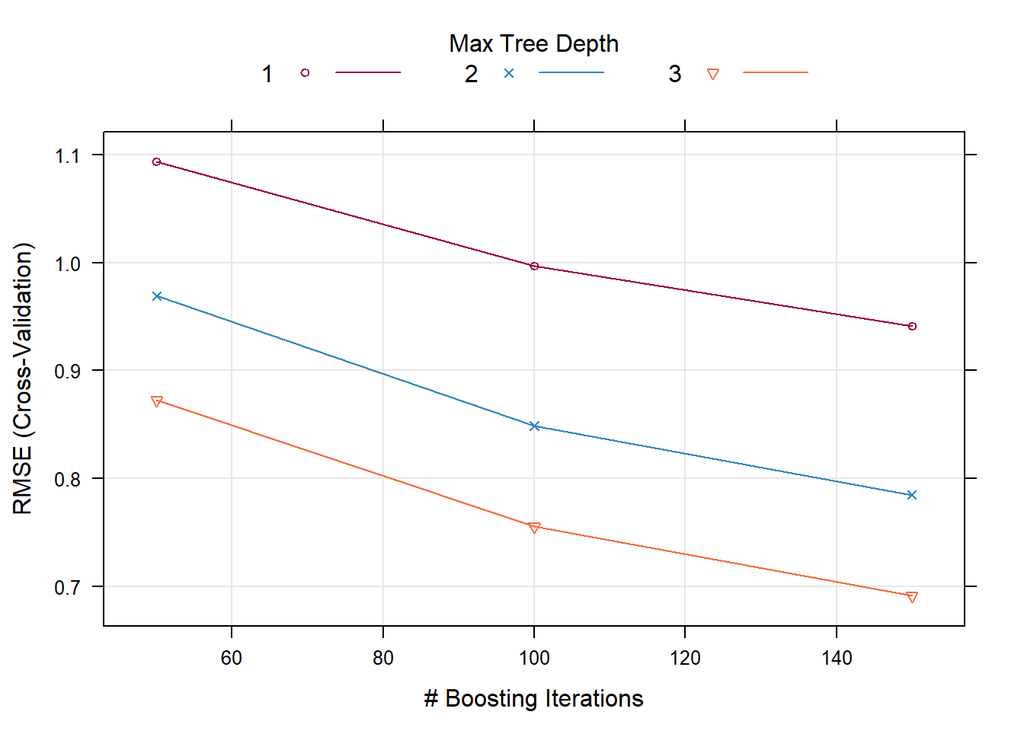

```r
  trellis.par.set(caretTheme())
  plot(gbm_model)
```

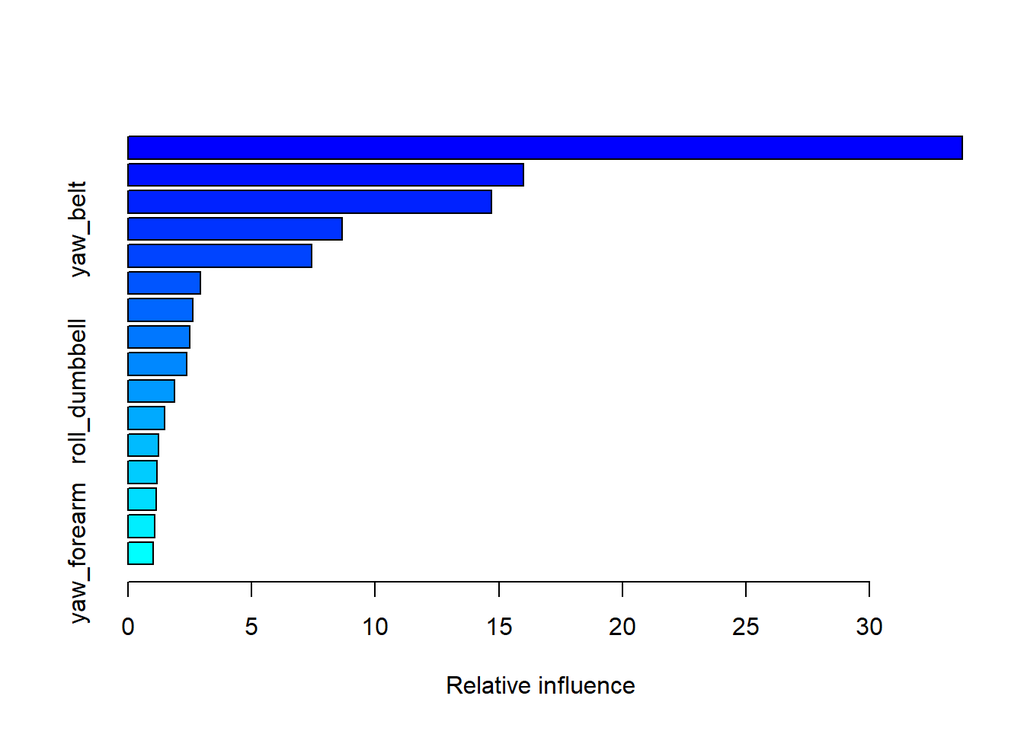

```
##                                       var   rel.inf
## roll_belt                       roll_belt 33.752094
## pitch_forearm               pitch_forearm 15.998537
## roll_forearm                 roll_forearm 14.699880
## yaw_belt                         yaw_belt  8.675100
## pitch_belt                     pitch_belt  7.445905
## total_accel_belt         total_accel_belt  2.928083
## yaw_dumbbell                 yaw_dumbbell  2.622590
## yaw_arm                           yaw_arm  2.502491
## roll_arm                         roll_arm  2.363111
## roll_dumbbell               roll_dumbbell  1.870073
## total_accel_arm           total_accel_arm  1.497838
## pitch_dumbbell             pitch_dumbbell  1.221761
## pitch_arm                       pitch_arm  1.187460
## total_accel_dumbbell total_accel_dumbbell  1.135138
## total_accel_forearm   total_accel_forearm  1.069536
## yaw_forearm                   yaw_forearm  1.030404
```

```r
  summary(gbm_model$finalModel)
```

```r
  gbm_predict <- predict(gbm_model, testing_data)
  gbm_prediction <- chartr("12345", "ABCDE", round(gbm_predict, digits=0))

  summary(lm_model$finalModel)
```

```
##
## Call:
## lm(formula = .outcome ~ ., data = dat)
##
## Residuals:
##     Min      1Q  Median      3Q     Max
## -3.7241 -0.9839 -0.0674  0.8922  3.7157
##
## Coefficients:
##                        Estimate Std. Error t value Pr(>|t|)
## (Intercept)           3.601e-01  7.944e-02   4.533 5.87e-06 ***
## roll_belt            -4.737e-03  1.216e-03  -3.896 9.82e-05 ***
## roll_arm              1.657e-03  2.010e-04   8.243  < 2e-16 ***
## roll_dumbbell         7.636e-04  2.172e-04   3.516  0.00044 ***
## roll_forearm          9.796e-04  1.145e-04   8.552  < 2e-16 ***
## pitch_belt           -1.392e-02  1.482e-03  -9.393  < 2e-16 ***
## pitch_arm            -7.721e-03  3.767e-04 -20.497  < 2e-16 ***
## pitch_dumbbell       -5.788e-04  4.293e-04  -1.348  0.17767
## pitch_forearm         1.855e-02  4.633e-04  40.032  < 2e-16 ***
## yaw_belt             -6.957e-03  5.272e-04 -13.195  < 2e-16 ***
## yaw_arm               7.767e-04  1.752e-04   4.433 9.36e-06 ***
## yaw_dumbbell         -2.753e-03  2.288e-04 -12.031  < 2e-16 ***
## yaw_forearm          -8.186e-04  1.291e-04  -6.343 2.33e-10 ***
## total_accel_arm      -5.045e-03  1.131e-03  -4.461 8.21e-06 ***
## total_accel_belt      1.071e-01  8.423e-03  12.712  < 2e-16 ***
## total_accel_dumbbell  7.404e-05  1.537e-03   0.048  0.96158
## total_accel_forearm   3.604e-02  1.233e-03  29.225  < 2e-16 ***
## ---
## Signif. codes:  0 '***' 0.001 '**' 0.01 '*' 0.05 '.' 0.1 ' ' 1
##
## Residual standard error: 1.299 on 13720 degrees of freedom
## Multiple R-squared:  0.2293, Adjusted R-squared:  0.2284
## F-statistic: 255.2 on 16 and 13720 DF,  p-value: < 2.2e-16
```

```r
  lm_predict <‐ predict(lm_model,testing_data)
  lm_prediction <- chartr("12345", "ABCDE", round(lm_predict, digits=0))

  summary(rf_model$finalModel)
```

```
##                 Length Class      Mode
## call                6  -none-     call
## type                1  -none-     character
## predicted       13737  -none-     numeric
## mse                10  -none-     numeric
## rsq                10  -none-     numeric
## oob.times       13737  -none-     numeric
## importance         16  -none-     numeric
## importanceSD        0  -none-     NULL
## localImportance     0  -none-     NULL
## proximity           0  -none-     NULL
## ntree               1  -none-     numeric
## mtry                1  -none-     numeric
## forest             11  -none-     list
## coefs               0  -none-     NULL
## y               13737  -none-     numeric
## test                0  -none-     NULL
## inbag               0  -none-     NULL
## xNames             16  -none-     character
## problemType         1  -none-     character
## tuneValue           1  data.frame list
## obsLevels           1  -none-     logical
## param               2  -none-     list
```

```r
  rf_predict <‐  predict(rf_model,testing_data)
  rf_prediction <- chartr("12345", "ABCDE", round(rf_predict, digits=0))

  ## Comparisons
  conf.matrix <- round(prop.table(table(lm_prediction, gbm_prediction, rf_prediction), 3), 3)
  conf.matrix
```

```
## , , rf_prediction = A
##
##              gbm_prediction
## lm_prediction     A     B     C     D     E
##             A 0.143 0.000 0.000 0.000 0.000
##             B 0.286 0.286 0.000 0.000 0.000
##             C 0.143 0.143 0.000 0.000 0.000
##             D 0.000 0.000 0.000 0.000 0.000
##
## , , rf_prediction = B
##
##              gbm_prediction
## lm_prediction     A     B     C     D     E
##             A 0.000 0.000 0.000 0.000 0.000
##             B 0.000 0.250 0.000 0.000 0.000
##             C 0.000 0.125 0.375 0.000 0.000
##             D 0.000 0.000 0.250 0.000 0.000
##
## , , rf_prediction = C
##
##              gbm_prediction
## lm_prediction     A     B     C     D     E
##             A 0.000 0.000 0.000 0.000 0.000
##             B 0.000 0.000 0.000 0.000 0.000
##             C 0.000 0.000 1.000 0.000 0.000
##             D 0.000 0.000 0.000 0.000 0.000
##
## , , rf_prediction = D
##
##              gbm_prediction
## lm_prediction     A     B     C     D     E
##             A 0.000 0.000 0.000 0.000 0.000
##             B 0.000 0.000 0.000 0.000 0.000
##             C 0.000 0.000 0.000 1.000 0.000
##             D 0.000 0.000 0.000 0.000 0.000
##
## , , rf_prediction = E
##
##              gbm_prediction
## lm_prediction     A     B     C     D     E
##             A 0.000 0.000 0.000 0.000 0.000
##             B 0.000 0.000 0.333 0.000 0.000
##             C 0.000 0.000 0.000 0.333 0.333
##             D 0.000 0.000 0.000 0.000 0.000
```

CONCLUSIONS

The predicted cases for all three models is found below. The random forest model performed well and was used to predict the 20 cases for the quiz.

```r
  prediction_results <- cbind(gbm_prediction, lm_prediction, rf_prediction)
  kable(prediction_results) %>%
  kable_styling(bootstrap_options = "striped", full_width = F, position = "left")
```

| gbm_prediction | lm_prediction | rf_prediction |
| --- | --- | --- |
| C | D | B |
| A | C | A |
| B | B | B |
| B | B | A |
| B | B | A |
| E | C | E |
| D | C | D |
| C | D | B |
| A | A | A |
| B | C | A |
| C | C | B |
| C | C | C |
| C | C | B |
| A | B | A |
| D | C | E |
| C | B | E |
| A | B | A |
| C | C | B |
| B | C | B |
| B | B | B |